# Pranav Shikarpur | Eisha Ahmed

This report utilizes Python 3 and its associated libraries as well a dataset concerning student grades alonside many other reatures. Becoming familiar with these libraries and their associated function will be useful to follow along with this report. These libraries include Pandas, NumPy, Matplotlib, Statsmodels, and Scikit-learn.

> Links to the Python library documentations:
> - https://pandas.pydata.org/pandas-docs/stable/
> - https://numpy.org/doc/
> - https://matplotlib.org/
> - https://www.statsmodels.org/stable/index.html
> - https://scikit-learn.org/stable/

> Link to the relevant datasets:
> - https://www.kaggle.com/datasets/uciml/student-alcohol-consumption

### Importing Relevant Libraries

```python
import pandas as pd
import matplotlib.pyplot as plt
!pip install pingouin
import pingouin as pg
import numpy
import pylab

from sklearn.model_selection import train_test_split
from sklearn.linear_model import LinearRegression
from sklearn.metrics import mean_squared_error
from math import sqrt
```

## Data Retrieval

```python
url = "https://raw.githubusercontent.com/snpranav/dummy_project_dataset/main/student-mat.csv"
df = pd.read_csv(url)
```

### Dateset Description: Student Grades

This dataset portrays the results of a survey conducted of students taking both math and portuguese language courses in secondary school in Portugal. The survey contains information regarding the background of the student and their family life, their academic history, as well as their social life and activities. Some important variables in this dataset that can be analyzed in response to this background information are 'G1', 'G2', and 'G3'. These features refer to period one, period two, and final academic grades, where each period refers to an academic half-year. The dataset contains a total of 395 entries, meaning that 395 surveys of students were conducted as part of the data collection. (words: 111)

```python
df
```

|  | school | sex | age | address | famsize | Pstatus | Medu | Fedu | Mjob | Fjob | ... | famrel | freetime | goout | Dalc | Walc | health | absences | G1 | G2 | G3 |
| --- | --- | --- | --- | --- | --- | --- | --- | --- | --- | --- | --- | --- | --- | --- | --- | --- | --- | --- | --- | --- | --- |
| 0 | GP | F | 18 | U | GT3 | A | 4 | 4 | at_home | teacher | ... | 4 | 3 | 4 | 1 | 1 | 3 | 6 | 5 | 6 | 6 |
| 1 | GP | F | 17 | U | GT3 | T | 1 | 1 | at_home | other | ... | 5 | 3 | 3 | 1 | 1 | 3 | 4 | 5 | 5 | 6 |
| 2 | GP | F | 15 | U | LE3 | T | 1 | 1 | at_home | other | ... | 4 | 3 | 2 | 2 | 3 | 3 | 10 | 7 | 8 | 10 |
| 3 | GP | F | 15 | U | GT3 | T | 4 | 2 | health | services | ... | 3 | 2 | 2 | 1 | 1 | 5 | 2 | 15 | 14 | 15 |
| 4 | GP | F | 16 | U | GT3 | T | 3 | 3 | other | other | ... | 4 | 3 | 2 | 1 | 2 | 5 | 4 | 6 | 10 | 10 |
| ... | ... | ... | ... | ... | ... | ... | ... | ... | ... | ... | ... | ... | ... | ... | ... | ... | ... | ... | ... | ... | ... |
| 390 | MS | M | 20 | U | LE3 | A | 2 | 2 | services | services | ... | 5 | 5 | 4 | 4 | 5 | 4 | 11 | 9 | 9 | 9 |
| 391 | MS | M | 17 | U | LE3 | T | 3 | 1 | services | services | ... | 2 | 4 | 5 | 3 | 4 | 2 | 3 | 14 | 16 | 16 |
| 392 | MS | M | 21 | R | GT3 | T | 1 | 1 | other | other | ... | 5 | 5 | 3 | 3 | 3 | 3 | 3 | 10 | 8 | 7 |
| 393 | MS | M | 18 | R | LE3 | T | 3 | 2 | services | other | ... | 4 | 4 | 1 | 3 | 4 | 5 | 0 | 11 | 12 | 10 |
| 394 | MS | M | 19 | U | LE3 | T | 1 | 1 | other | at_home | ... | 3 | 2 | 3 | 3 | 3 | 5 | 5 | 8 | 9 | 9 |

395 rows × 33 columns

### Correlation between G1 and G3

```python
x = df['G1']
y = df['G3']
reg = pg.linear_regression(x,y)
reg.round(2)
```

|  | names | coef | se | T | pval | r2 | adj_r2 | CI[2.5%] | CI[97.5%] |
| --- | --- | --- | --- | --- | --- | --- | --- | --- | --- |
| 0 | Intercept | -1.65 | 0.47 | -3.48 | 0.0 | 0.64 | 0.64 | -2.59 | -0.72 |
| 1 | G1 | 1.11 | 0.04 | 26.57 | 0.0 | 0.64 | 0.64 | 1.02 | 1.19 |

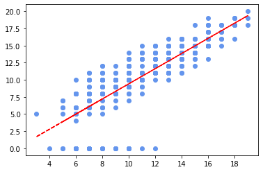

```python
plt.scatter(df['G1'], df['G3'], color = 'cornflowerblue')

# calc the trendline
z = numpy.polyfit(df['G1'], df['G3'], 1)
p = numpy.poly1d(z)
pylab.plot(df['G1'],p(df['G1']),"r--")
# the line equation:

plt.show() # Depending on whether you use IPython or interactive mode, etc.
```

### Corrleation between G2 and G3

```python
x = df['G2']
y = df['G3']
reg = pg.linear_regression(x,y)
reg.round(2)
```

|  | names | coef | se | T | pval | r2 | adj_r2 | CI[2.5%] | CI[97.5%] |
| --- | --- | --- | --- | --- | --- | --- | --- | --- | --- |
| 0 | Intercept | -1.39 | 0.30 | -4.69 | 0.0 | 0.82 | 0.82 | -1.98 | -0.81 |
| 1 | G2 | 1.10 | 0.03 | 42.14 | 0.0 | 0.82 | 0.82 | 1.05 | 1.15 |

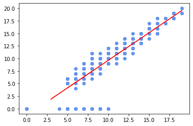

```python
plt.scatter(df['G2'], df['G3'], color = 'cornflowerblue')

# calc the trendline
z = numpy.polyfit(df['G2'], df['G3'], 1)
p = numpy.poly1d(z)
pylab.plot(df['G1'],p(df['G1']),"r--")

plt.show() # Depending on whether you use IPython or interactive mode, etc.
```

### Correlation between failures and G3

```python
x = df['failures']
y = df['G3']
reg = pg.linear_regression(y,x)
reg.round(2)
```

|  | names | coef | se | T | pval | r2 | adj_r2 | CI[2.5%] | CI[97.5%] |
| --- | --- | --- | --- | --- | --- | --- | --- | --- | --- |
| 0 | Intercept | 0.94 | 0.09 | 10.86 | 0.0 | 0.13 | 0.13 | 0.77 | 1.11 |
| 1 | G3 | -0.06 | 0.01 | -7.66 | 0.0 | 0.13 | 0.13 | -0.07 | -0.04 |

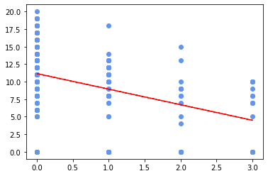

```python
plt.scatter(df['failures'], df['G3'], color = 'cornflowerblue')
# calc the trendline
z = numpy.polyfit(df['failures'], df['G3'], 1)
p = numpy.poly1d(z)
pylab.plot(df['failures'],p(df['failures']),"r--")
plt.show() # Depending on whether you use IPython or interactive mode, etc.
```

### Correlation between studytime and G3

```python
x = df['studytime']
y = df['G3']
reg = pg.linear_regression(x,y)
reg.round(2)
```

|  | names | coef | se | T | pval | r2 | adj_r2 | CI[2.5%] | CI[97.5%] |
| --- | --- | --- | --- | --- | --- | --- | --- | --- | --- |
| 0 | Intercept | 9.33 | 0.60 | 15.46 | 0.00 | 0.01 | 0.01 | 8.14 | 10.51 |
| 1 | studytime | 0.53 | 0.27 | 1.95 | 0.05 | 0.01 | 0.01 | -0.00 | 1.07 |

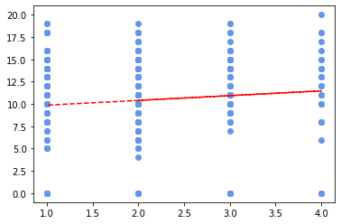

```python
plt.scatter(df['studytime'], df['G3'], color = 'cornflowerblue')
# calc the trendline
z = numpy.polyfit(df['studytime'], df['G3'], 1)
p = numpy.poly1d(z)
pylab.plot(df['studytime'],p(df['studytime']),"r--")
```

### Correlation between absences and G3

```python
x = df['absences']
y = df['G3']
reg = pg.linear_regression(x,y)
reg.round(2)
```

|  | names | coef | se | T | pval | r2 | adj_r2 | CI[2.5%] | CI[97.5%] |
| --- | --- | --- | --- | --- | --- | --- | --- | --- | --- |
| 0 | Intercept | 10.30 | 0.28 | 36.35 | 0.0 | 0.0 | -0.0 | 9.75 | 10.86 |
| 1 | absences | 0.02 | 0.03 | 0.68 | 0.5 | 0.0 | -0.0 | -0.04 | 0.08 |

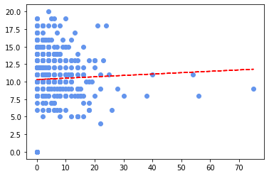

```python
plt.scatter(df['absences'], df['G3'], color = 'cornflowerblue')
# calc the trendline
z = numpy.polyfit(df['absences'], df['G3'], 1)
p = numpy.poly1d(z)
pylab.plot(df['absences'],p(df['absences']),"r--")
```

## Correlation between Daily Alcohol Consumption (Dalc) and G3

```python
x = df['Dalc']
y = df['G3']
reg = pg.linear_regression(x,y)
reg.round(2)
```

[output not shown]

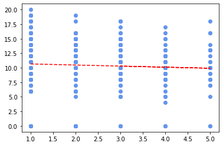

```python
plt.scatter(df['Dalc'], df['G3'], color = 'cornflowerblue')
# calc the trendline
z = numpy.polyfit(df['Dalc'], df['G3'], 1)
p = numpy.poly1d(z)
pylab.plot(df['Dalc'],p(df['Dalc']),"r--")
```

## Correlation between Weekend Alcohol Consumption (Walc) and G3

```python
x = df['Dalc']
y = df['G3']
reg = pg.linear_regression(x,y)
reg.round(2)
```

[output not shown]

```python
plt.scatter(df['Walc'], df['G3'], color = 'cornflowerblue')
# calc the trendline
z = numpy.polyfit(df['Walc'], df['G3'], 1)
p = numpy.poly1d(z)
pylab.plot(df['Walc'],p(df['Walc']),"r--")
```

[output not shown]

From our initial hypothesis and the articles we had read, our assumption was that alcohol does affect exam grades. Hence we decided to see if we could build a regression model to see this correlation. We built 2 regression models to see how different features in our dataset affected grades.

### First Experiment

Initially, we took the parameters "faliures", "studytime", "absences", "G2" to get a basic understanding to see if purely academic parameters such as past failiures, studytime, etc affected final grades.

As we can see, the accuracy we got with this was 78.84% which is very good. And shows that academic factors have a strong corellation with grades.

### Second Experiment

Our assumption was that we should technically see the inverse of this while considering Alcohol's affect on grades (i.e. Less alcohol conspution should technically imply higher grades) - but the results were surprising. We found that there was no correlation. On building the linear regression models with the features "goout", "Walc", "Dalc", and "studytime" vs "G3", we can see that the accuracy is 3.15% which is extremely low. From the scatter plot we can also notice that there is no specific trend we get from this.

#### Methodology

- Extracted the features I needed
- Used sklearn's `test_train_split` method to split the dataset up into test and train data.
- Fit the model to a linear regression curve on the train data.
- Calculate the accuracy against the test data.

```
Accuracy:  0.7884791402551777
```

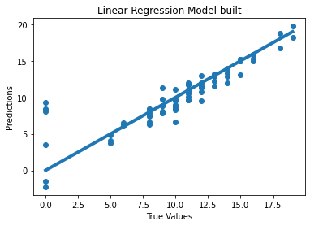

```python
# Create a dataframe with only the columns we want to use
df2 = df[['failures', 'studytime', 'absences', 'G2']]
df2.head()

x = df2
y = df['G3']

# Split the data into train and test sets
x_train, x_test, y_train, y_test = train_test_split(x, y, test_size=0.2, random_state=15)

model = LinearRegression()

model.fit(x_train, y_train)

y_pred = model.predict(x_test)

score = model.score(x_test, y_test)
print("Accuracy: ", score)

# Graph test and train data to check for overfitting
plt.scatter(y_test, y_pred)
plt.xlabel('True Values')
plt.ylabel('Predictions')

# Graph linear regression line
plt.plot([y_test.min(), y_test.max()], [y_test.min(), y_test.max()], '-', lw=4)

plt.title('Linear Regression Model built')
```

```
Accuracy:  0.031511460028112226
```

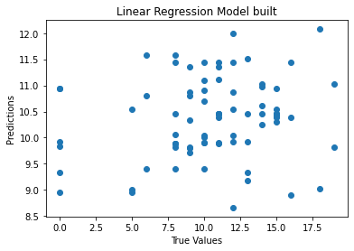

```python
# Create a dataframe with only the columns we want to use
df2 = df[['goout','studytime', 'Walc', 'Dalc']]
df2.head()

x = df2
y = df['G3']

# Split the data into train and test sets
x_train, x_test, y_train, y_test = train_test_split(x, y, test_size=0.2, random_state=15)

model = LinearRegression()

model.fit(x_train, y_train)

y_pred = model.predict(x_test)

score = model.score(x_test, y_test)
print("Accuracy: ", score)

# Graph test and train data to check for overfitting
plt.scatter(y_test, y_pred)
plt.xlabel('True Values')
plt.ylabel('Predictions')

plt.title('Linear Regression Model built')
```